fossil

# Housekeeper models, dug back up.

The authors fitted their models in R but never released the code. We rebuilt Models 1 and 2 from the paper's text as the R package hkselect and reran them on the paper's breast cancer data and on Vandesompele et al.'s data. Of 26 results we tried, 5 came back exact, 12 agree, 5 partly and 4 differ.

See every result

## Fig. 1

Fig. 1. Relative expression of six genes in 80 breast tumours, raw (a) and on a log scale (b); tumours ordered by the mean of their log values.

Agrees

Published

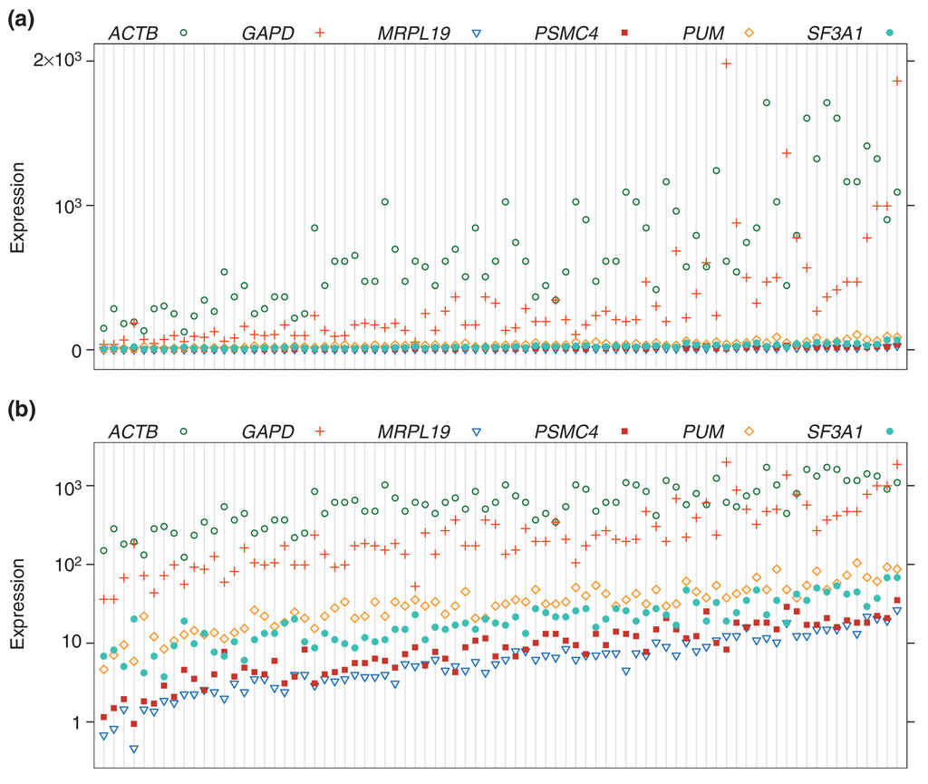

Our run

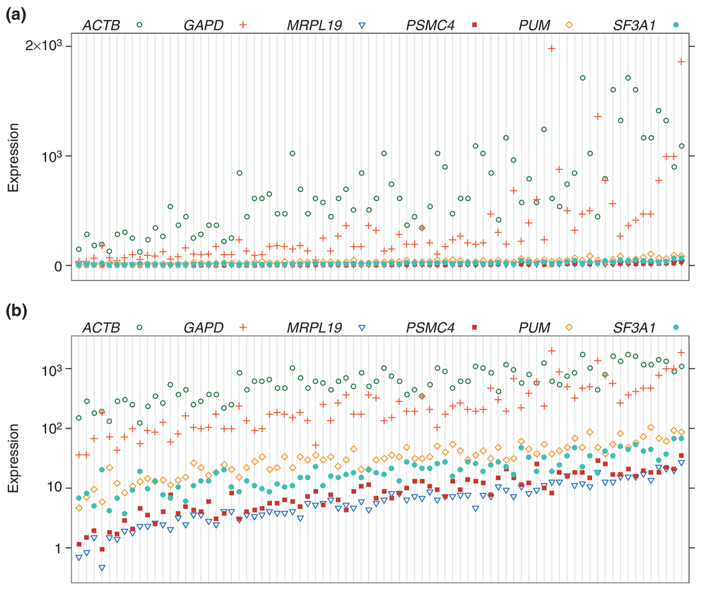

**Fig. 1a, raw expression of six genes in 80 breast tumours**

97.36% within 2 px (pass 90.0%, best control 79.7%), Agrees

**Fig. 1b, the same on a log scale**

95.87% within 2 px (pass 90.0%, best control 71.5%), Agrees

## Tables 1 to 4

Each table as printed and from our run. A value of ours matches when it rounds to the printed one.

Differs

Table 1. Model 1a standard deviations of log expression, with 95% intervals. Paper, then ours; * not as printed. Partly agrees

| Gene | Paper | Ours | nlme intervals() over 24 parameterizations |
| --- | --- | --- | --- |
| MRPL19 | 0.218 (0.168, 0.284) | 0.218 (0.169, 0.282) | lower 0.1661-0.1687, upper 0.2821-0.2866 |
| PUM1 | 0.265 (0.215, 0.328) | 0.265 (0.214, 0.330) | lower 0.2123-0.2156, upper 0.3269-0.3320 |
| PSMC4 | 0.288 (0.235, 0.352) | 0.288 (0.235, 0.353) | lower 0.2341-0.2377, upper 0.3482-0.3536 |
| SF3A1 | 0.393 (0.327, 0.472) | 0.393 (0.327, 0.471) | lower 0.3261-0.3269, upper 0.4715-0.4727 |
| ACTB | 0.448 (0.376, 0.533) | 0.448 (0.376, 0.533) | lower 0.3753-0.3776, upper 0.5308-0.5340 |
| GAPD | 0.519 (0.439, 0.613) | 0.519 (0.439, 0.613) | lower 0.4385-0.4404, upper 0.6115-0.6142 |

The printed bounds are nlme's approximate intervals, whose numerical Hessian moves them in the third decimal with the order of the rows and the contrasts; across 24 such parameterizations nlme 3.1-164 reaches all 12 printed bounds. Ours, from an accurate Hessian, are within 0.002 of every printed bound.

Table 2. Best gene set of each size and the SD of its log geometric mean. * not as printed. Partly agrees

| Size | Paper | SD | Ours | SD | Printed formula, SD |
| --- | --- | --- | --- | --- | --- |
| 1 | MRPL19 | 0.2182 | MRPL19 | 0.2182 | 0.2182 |
| 2 | PUM1, MRPL19 | 0.1718 | MRPL19, PUM1 | 0.1718 | 0.2430 |
| 3 | PSMC4, MRPL19, PUM1 | 0.1494 | MRPL19, PSMC4, PUM1 | 0.1494 | 0.2587 |
| 4 | PSMC4, MRPL19, PUM1, SP3A1 | 0.1490 | MRPL19, PSMC4, SF3A1, PUM1 | 0.1490 | 0.2979 |
| 5 | PSMC4, MRPL19, SF3A1, PUM1, ACTB | 0.1491 | MRPL19, PSMC4, SF3A1, PUM1, ACTB | 0.1491 | 0.3333 |
| 6 | PSMC4, MRPL19, SF3A1, PUM1, GAPD, ACTB | 0.1513 | MRPL19, PSMC4, SF3A1, PUM1, GAPD, ACTB | 0.1514 * | 0.3707 |

Table 3. Model 2: gene SDs sigma_j, then tissue multipliers varsigma_k (bone marrow 1). * not as printed. Differs

|  | Paper | Ours |
| --- | --- | --- |
| GAPD | 0.211 | 0.206 * |
| UBC | 0.226 | 0.221 * |
| HPRT1 | 0.227 | 0.221 * |
| YWHAZ | 0.232 | 0.225 * |
| SDHA | 0.255 | 0.249 * |
| RPL13A | 0.339 | 0.331 * |
| TBP | 0.339 | 0.330 * |
| HMBS | 0.431 | 0.421 * |
| ACTB | 0.460 | 0.436 * |
| B2M | 0.562 | 0.548 * |
| BM | 1.000 | 1.000 |
| FIB | 1.204 | 1.237 * |
| NB | 1.582 | 1.625 * |
| LEU | 1.879 | 1.939 * |
| POOL | 2.014 | 2.068 * |

Every gene SD comes out below the printed one, by 2.1 to 5.2% (ACTB the most), in the same order. Table 3's figures are not a rounding of ours, and none of the variant fits below reaches them; Fig. 3 draws the printed values, so the authors' fit, or their copy of the data, differed from ours.

Table 4. Minimax-MSE gene set with at most each number of members. * not as printed. Last two columns: the same search with the bias of a set taken as the mean of its genes' biases. Partly agrees

| Size | Paper | MSE | Ours | MSE | Mean bias | MSE |
| --- | --- | --- | --- | --- | --- | --- |
| 1 | RPL13A | 0.544 | RPL13A | 0.545 * | RPL13A | 0.545 |
| 2 | HPRT1, UBC | 0.328 | HPRT1, UBC | 0.328 | HPRT1, UBC | 0.160 |
| 3 | HPRT1, RPL13A, UBC | 0.136 | HPRT1, RPL13A, UBC | 0.137 * | HPRT1, UBC, YWHAZ | 0.086 |
| 4 | HPRT1, RPL13A, UBC | 0.136 | HPRT1, RPL13A, UBC | 0.137 * | GAPD, HPRT1, SDHA, YWHAZ | 0.069 |
| 5 | HPRT1, RPL13A, UBC | 0.136 | HPRT1, RPL13A, UBC | 0.137 * | GAPD, HPRT1, TBP, UBC, YWHAZ | 0.063 |
| 6 | ACTB, HPRT1, SDHA, TBP, UBC, YWHAZ | 0.131 | ACTB, HPRT1, SDHA, TBP, UBC, YWHAZ | 0.130 * | GAPD, HPRT1, RPL13A, TBP, UBC, YWHAZ | 0.050 |
| 7 | ACTB, HPRT1, RPL13A, SDHA, TBP, UBC, YWHAZ | 0.064 | ACTB, HPRT1, RPL13A, SDHA, TBP, UBC, YWHAZ | 0.064 | GAPD, HPRT1, RPL13A, SDHA, TBP, UBC, YWHAZ | 0.047 |
| 8 | ACTB, HPRT1, RPL13A, SDHA, TBP, UBC, YWHAZ | 0.064 | ACTB, HPRT1, RPL13A, SDHA, TBP, UBC, YWHAZ | 0.064 | GAPD, HPRT1, RPL13A, SDHA, TBP, UBC, YWHAZ | 0.047 |
| 9 | ACTB, HPRT1, RPL13A, SDHA, TBP, UBC, YWHAZ | 0.064 | ACTB, HPRT1, RPL13A, SDHA, TBP, UBC, YWHAZ | 0.064 | GAPD, HPRT1, RPL13A, SDHA, TBP, UBC, YWHAZ | 0.047 |
| 10 | ACTB, B2M, GAPD, HMBS, HPRT1, RPL13A, SDHA, TBP, UBC, YWHAZ | 0.049 | ACTB, B2M, GAPD, HMBS, HPRT1, RPL13A, SDHA, TBP, UBC, YWHAZ | 0.049 | GAPD, HPRT1, RPL13A, SDHA, TBP, UBC, YWHAZ | 0.047 |

Every set comes back; 5 of 10 MSEs are 0.001 off. They follow from Model 2's SDs (table3.sigma, open): with Table 3's printed SDs in place of ours, a sensitivity variant, 9 of 10 MSEs are as printed and the tenth (0.543 against 0.544) within Table 3's rounding.

## Fig. 2

Fig. 2. Vandesompele et al.'s data on a log scale: ten genes by sample and tissue type.

Agrees

Published

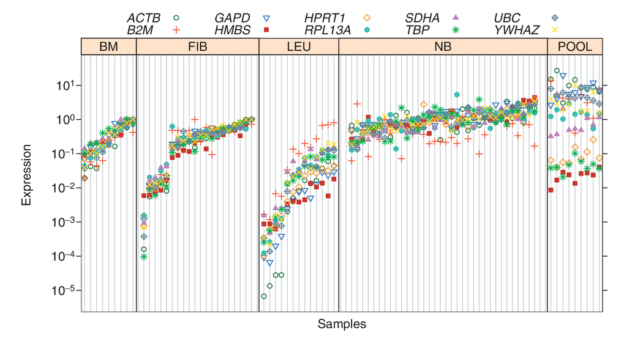

Our run

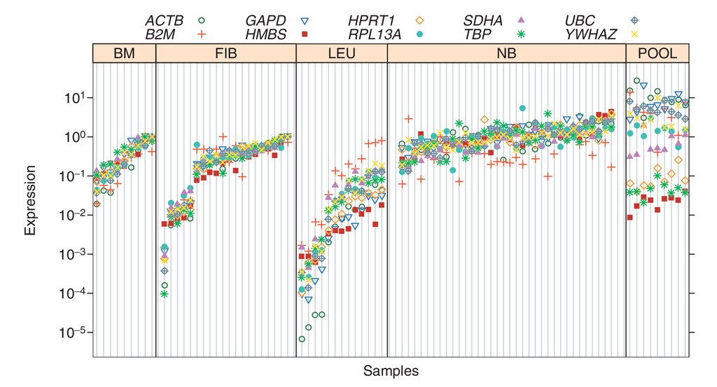

**Fig. 2, Vandesompele et al.'s data by tissue type**

93.37% within 2 px (pass 90.0%, best control 85.7%), Agrees

## Fig. 3

Fig. 3. Mean squared error of each gene in each tissue type, split into squared bias (red) and variance (white), signed by the bias.

Partly agrees

Published

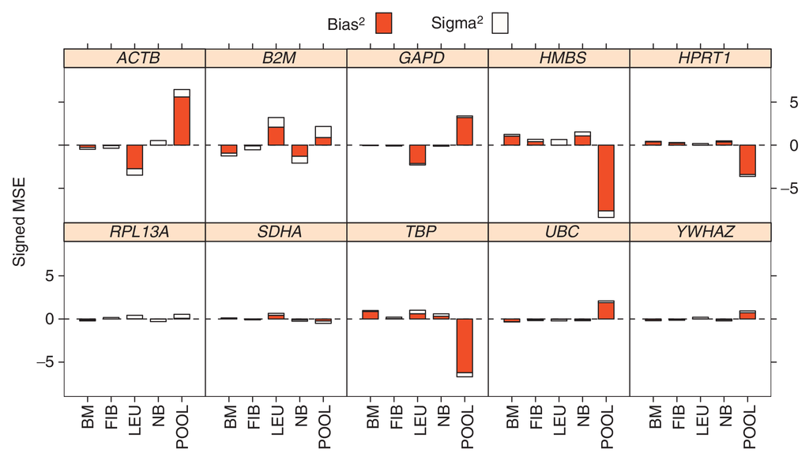

Our run

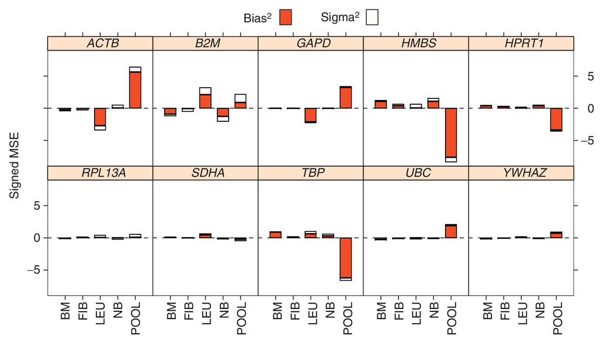

**Fig. 3, signed MSE of each gene by tissue type**

99.66% within 2 px (pass 98.0%, best control 95.9%), Agrees

**Fig. 3, squared biases (bar heights in the publisher's R graphics file)**

50 of 50 fields as printed, Agrees

**Fig. 3, variances (bar heights in the publisher's R graphics file)**

10 of 50 fields as printed, Partly agrees

## Every result

Every figure, table and claim of the paper, with its verdict from results.json.

Result

Verdict

Measure

Why

Fig. 1a, raw expression of six genes in 80 breast tumours

Agrees

97.36% within 2 px (pass 90.0%, best control 79.7%)

Fig. 1b, the same on a log scale

Agrees

95.87% within 2 px (pass 90.0%, best control 71.5%)

Table 1, Model 1a standard deviations

Exact

6 of 6 fields as printed

- MRPL19 SD: paper 0.218, ours **0.218166**
- PUM1 SD: paper 0.265, ours **0.265491**
- PSMC4 SD: paper 0.288, ours **0.287701**
- SF3A1 SD: paper 0.393, ours **0.392586**
- ACTB SD: paper 0.448, ours **0.447691**
- GAPD SD: paper 0.519, ours **0.518932**

Table 1, 95% confidence intervals

Partly agrees

6 of 12 fields as printed

- MRPL19 lower: paper 0.168, ours **0.16866**
- MRPL19 upper: paper 0.284, ours **0.282204**
- PUM1 lower: paper 0.215, ours **0.213813**
- PUM1 upper: paper 0.328, ours **0.329659**
- PSMC4 lower: paper 0.235, ours **0.234658**
- PSMC4 upper: paper 0.352, ours **0.352734**
- SF3A1 lower: paper 0.327, ours **0.326941**
- SF3A1 upper: paper 0.472, ours **0.471412**
- ACTB lower: paper 0.376, ours **0.376238**
- ACTB upper: paper 0.533, ours **0.532714**
- GAPD lower: paper 0.439, ours **0.439252**
- GAPD upper: paper 0.613, ours **0.613065**

The printed bounds are nlme's approximate intervals, whose numerical Hessian moves them in the third decimal with the order of the rows and the contrasts; across 24 such parameterizations nlme 3.1-164 reaches all 12 printed bounds. Ours, from an accurate Hessian, are within 0.002 of every printed bound.

Text: Model 1a has the best BIC of Models 1a, 1b and 1c

Agrees

BIC (REML) Model 1a 988.3, 1b 1012.4, 1c 990.6 (rho 0.31); Model 1a lowest

Text: microarray-selected genes against GAPD and ACTB, p = 0.0014

Agrees

1 of 1 fields as printed

- p, microarray-selected genes against GAPD and ACTB: paper 0.0014, ours **0.00138607**

Table 2, best gene set of each size and the SD of its log geometric mean

Partly agrees

10 of 11 fields as printed, 1 paper errors

- size 1 set: paper MRPL19, ours **MRPL19**
- size 1 SD: paper 0.2182, ours **0.218166**
- size 2 set: paper MRPL19,PUM1, ours **MRPL19,PUM1**
- size 2 SD: paper 0.1718, ours **0.171815**
- size 3 set: paper MRPL19,PSMC4,PUM1, ours **MRPL19,PSMC4,PUM1**
- size 3 SD: paper 0.1494, ours **0.149389**
- size 4 set: paper MRPL19,PSMC4,PUM1,SP3A1, ours **MRPL19,PSMC4,PUM1,SF3A1**
- size 4 SD: paper 0.1490, ours **0.14895**
- size 5 set: paper ACTB,MRPL19,PSMC4,PUM1,SF3A1, ours **ACTB,MRPL19,PSMC4,PUM1,SF3A1**
- size 5 SD: paper 0.1491, ours **0.149051**
- size 6 set: paper ACTB,GAPD,MRPL19,PSMC4,PUM1,SF3A1, ours **ACTB,GAPD,MRPL19,PSMC4,PUM1,SF3A1**
- size 6 SD: paper 0.1513, ours **0.151355**

Methods: the printed variance of a set's log geometric mean (divided by the set size)

Differs

the printed formula (divided by the set size) gives 1 of 6 Table 2 values; divided by its square, 5 of 6

The formula divides by the set size where Table 2 divides by its square: on the paper's own Table 1 the best pair gives 0.1716 with the square (printed 0.1718) and 0.2426 with the size.

Text: the four-gene set is lowest, three genes barely worse, two far worse

Agrees

the four-gene set is lowest (0.1490); three genes 0.1494, 0.0004 more; two genes 0.1718, 0.0224 more than three

Text: the SDs of Table 2 are about the coefficients of variation on the original scale

Agrees

the coefficient of variation sqrt(exp(SD^2) - 1) of each Table 2 normaliser is within 1.2% of its SD

Text: geNorm M-values give the same ranking except PUM1 and PSMC4, with MRPL19 and PSMC4 an unordered best pair

Exact

5 of 5 fields as printed

- unordered best pair: paper MRPL19,PSMC4, ours **MRPL19,PSMC4**
- rank 3: paper PUM1, ours **PUM1**
- rank 4: paper SF3A1, ours **SF3A1**
- rank 5: paper ACTB, ours **ACTB**
- rank 6: paper GAPD, ours **GAPD**

Methods: the printed bounds on the M-value under Model 1

Differs

under Model 1a's SDs (R = 2.38) the printed bounds sigma_j^2 sqrt(1 + 1/R^2) <= M_j <= sigma_j^2 sqrt(1 + R^2) fail; with sigma_j in place of sigma_j^2 they hold

The bounds print sigma_j^2 where sigma_j belongs (M is a mean of SDs): with sigma_j they hold for Model 1a's SDs, with sigma_j^2 they fail.

Methods: the four candidate genes chosen from microarrays

Not attempted

not attempted

A SAS selection of genes with 'a small range of expression' and 'the least variance' on 62 arrays (Perou et al. 2000 and cell lines), with no thresholds; it cannot be rerun as described, and its result (the four genes) is the paper's input, not one of its results.

Fig. 2, Vandesompele et al.'s data by tissue type

Agrees

93.37% within 2 px (pass 90.0%, best control 85.7%)

Table 3, Model 2 gene SDs

Differs

0 of 10 fields as printed

- GAPD: paper 0.211, ours **0.206485**
- UBC: paper 0.226, ours **0.220758**
- HPRT1: paper 0.227, ours **0.220848**
- YWHAZ: paper 0.232, ours **0.225498**
- SDHA: paper 0.255, ours **0.249182**
- RPL13A: paper 0.339, ours **0.330767**
- TBP: paper 0.339, ours **0.330164**
- HMBS: paper 0.431, ours **0.420763**
- ACTB: paper 0.460, ours **0.435995**
- B2M: paper 0.562, ours **0.548206**

Every gene SD comes out below the printed one, by 2.1 to 5.2% (ACTB the most), in the same order. Table 3's figures are not a rounding of ours, and none of the variant fits below reaches them; Fig. 3 draws the printed values, so the authors' fit, or their copy of the data, differed from ours.

Table 3, Model 2 tissue multipliers

Differs

0 of 4 fields as printed

- FIB: paper 1.204, ours **1.236567**
- NB: paper 1.582, ours **1.625137**
- LEU: paper 1.879, ours **1.939134**
- POOL: paper 2.014, ours **2.067805**

The same gap as the gene SDs (table3.sigma): our multipliers are 2.7 to 3.2% higher, so outside bone marrow the SDs varsigma_k sigma_j come within 2.7% of the printed products (bone marrow, where the multiplier is 1, carries the gene SDs' 2.1 to 5.2%).

Table 3, the order of the genes (GAPD lowest, then UBC, HPRT1, YWHAZ)

Exact

9 of 9 fields as printed

- rank 1: paper GAPD, ours **GAPD**
- rank 2: paper UBC, ours **UBC**
- rank 3: paper HPRT1, ours **HPRT1**
- rank 4: paper YWHAZ, ours **YWHAZ**
- rank 5: paper SDHA, ours **SDHA**
- rank 8: paper HMBS, ours **HMBS**
- rank 9: paper ACTB, ours **ACTB**
- rank 10: paper B2M, ours **B2M**
- ranks 6-7 (printed as a tie, 0.339): paper RPL13A,TBP, ours **RPL13A,TBP**

Methods: Model 2 has the best BIC of six variance structures

Agrees

BIC (REML) Model 2 2241.0; common 2367.4, gene 2276.2, tissue 2334.6, unstructured 2370.8, exchangeable 2245.4

Text: the top five genes by mean geNorm rank over tissue types are Table 3's top five, in order

Exact

5 of 5 fields as printed

- rank 1 by mean geNorm rank over tissue types: paper GAPD, ours **GAPD**
- rank 2 by mean geNorm rank over tissue types: paper UBC, ours **UBC**
- rank 3 by mean geNorm rank over tissue types: paper HPRT1, ours **HPRT1**
- rank 4 by mean geNorm rank over tissue types: paper YWHAZ, ours **YWHAZ**
- rank 5 by mean geNorm rank over tissue types: paper SDHA, ours **SDHA**

Table 4, minimax-MSE gene sets

Partly agrees

15 of 20 fields as printed

Every set comes back; 5 of 10 MSEs are 0.001 off. They follow from Model 2's SDs (table3.sigma, open): with Table 3's printed SDs in place of ours, a sensitivity variant, 9 of 10 MSEs are as printed and the tenth (0.543 against 0.544) within Table 3's rounding.

Fig. 3, signed MSE of each gene by tissue type

Agrees

99.66% within 2 px (pass 98.0%, best control 95.9%)

Fig. 3, squared biases (bar heights in the publisher's R graphics file)

Agrees

50 of 50 fields as printed

Fig. 3, variances (bar heights in the publisher's R graphics file)

Partly agrees

10 of 50 fields as printed

Text: ACTB plus TBP in pooled tissues, MSE 0.35 against individual MSEs above 6

Partly agrees

3 of 4 fields as printed

- MSE of the log-average of ACTB and TBP, pooled tissues: paper 0.35, ours **0.33717**
- ACTB individual MSE above 6: paper true, ours **true**
- TBP individual MSE above 6: paper true, ours **true**
- ACTB and TBP biases in opposite directions: paper true, ours **true**

Text: 80 tumours and 6 genes; 10 genes in 5 tissue types

Exact

4 of 4 fields as printed

- breast tumour samples: paper 80, ours **80**
- genes assayed in breast tumours: paper 6, ours **6**
- genes in Vandesompele et al.'s data: paper 10, ours **10**
- tissue types: paper 5, ours **5**

The claims recomputed from the paper's own tables and Fig. 3

Agrees

8 of 8 claims hold on the paper's own numbers: Table 2's best pair from Table 1, divided by the squared set size (holds, 0.1716 against 0.1718 (the set size gives 0.2426)); the four-gene set lowest in Table 2 (holds, 0.1490); three genes barely worse than four, two far worse (holds, 0.0004 and 0.0224); GAPD lowest in Table 3, then UBC, HPRT1, YWHAZ (holds); ACTB plus TBP in pooled tissues 0.35 (bias of the set summed) (holds, 0.349 (the mean of the biases gives 0.335)); ACTB and TBP individual MSEs in pooled tissues above 6 (holds, 6.45 and 6.70); Table 4's ten-gene MSE from Table 3 (no bias) (holds, 0.0490); Table 4's single gene RPL13A from Table 3 and Fig. 3, within Table 3's rounding (holds, 0.5435 against 0.544)

Table 5, primers

Not attempted

not attempted

Primer sequences, lengths, GC content and melting temperatures: laboratory reagents, nothing computed.

R package hkselect and its tutorial

Agrees

R package hkselect: R CMD check OK; tests 23 passed, 0 failed, 0 skipped; tutorial rendering equals the committed TUTORIAL.md (figures by name)

The main claims hold: MRPL19 is the best single gene and MRPL19, PUM1 and PSMC4 the chosen three-gene normaliser in breast cancer, and HPRT1, RPL13A and UBC the best small universal set. Of the results that do not match, Table 1's intervals differ in the third decimal as nlme's own do, two are slips in printed formulas, one is Table 2's last digit, and the rest follow from Model 2's SDs, which stay 2 to 5% below Table 3's for a reason we did not find.

## What came back

**Model 1a**

All six standard deviations of Table 1 as printed, from the paper's own data and the nlme model it names.

**Table 2**

Every best gene set, and five of the six standard deviations as printed.

**The p value**

p = 0.0014, from a likelihood ratio test the paper does not name.

**Fig. 3**

All 50 squared biases within the resolution of the publisher's R graphics file.

**Table 4**

Every minimax gene set, once the bias of a set is the sum of its genes' biases, as the paper's own ACTB and TBP example also needs.

## What stayed buried

- Model 2's standard deviations: ours stay 2 to 5% below Table 3, and no variant fit we tried reaches it.
- Table 2's six-gene value, 0.000004 on the other side of a rounding boundary.
- How the paper computed its confidence intervals; nlme's own spread covers every printed bound.

The main claims hold: MRPL19 is the best single gene and MRPL19, PUM1 and PSMC4 the chosen three-gene normaliser in breast cancer, and HPRT1, RPL13A and UBC the best small universal set. Of the results that do not match, Table 1's intervals differ in the third decimal as nlme's own do, two are slips in printed formulas, one is Table 2's last digit, and the rest follow from Model 2's SDs, which stay 2 to 5% below Table 3's for a reason we did not find.

## What we matched

What we matched, and how.

**Tables**

Each value against the printed one at its printed precision; gene sets as sets.

**Figs 1 and 2**

Our points drawn on the published pixel grid with the published markers, scored both ways within 2 px, against wrong inputs and near misses.

**Fig. 3**

The bars scored the same way, and every bar height read from the publisher's R graphics file.

**Text**

Each claim checked first on the paper's own tables (8 of 8 hold there), then on our run.